# Exploring Border Crossing API

# Getting data from the API

Libraries/setup

```r
#install.packages("httr")

library(httr)
library(lubridate)
library(tidyverse)

options(stringsAsFactors = FALSE)
```

Setup the URL and path for the API call. Anything after the ? in path will be the query from the API. Here format = CSV

```r
url <- "http://www.cascadegatewaydata.com"
path <- "Crossing/?format=CSV"
raw.result <- GET(url = url, path= path)
```

For easier to read code, you can use the query argument:

```r
url <- "http://www.cascadegatewaydata.com"
path <- "Crossing"
query = list(format = "CSV")
raw.result <- GET(url = url, path= path, query = query)
```

Exploring result:

```r
names(raw.result)
```

```
 [1] "url"         "status_code" "headers"     "all_headers" "cookies"     "content"     "date"        "times"       "request"
[10] "handle"
```

Look at status_code. Result of 200 tells us the server received the request

```r
raw.result$status_code
```

```
[1] 200
```

For more detailed messaging use http_status

```r
http_status(raw.result)
```

```
$category
[1] "Success"

$reason
[1] "OK"

$message
[1] "Success: (200) OK"
```

Look at the content. It is unicode and not useful

```r
raw.result$content
```

[output not shown]

Instead use content function

```r
content(raw.result)
```

| ID | Name | DirectionsOfTravel | LaneTypes |
| --- | --- | --- | --- |
| 134 | Peace Arch | Southbound,Northbound | Car,Nexus |
| 135 | Pacific Highway | Southbound,Northbound | Car,Bus,Fast,Nexus,Truck |
| 136 | Lynden/Aldergrove | Northbound,Southbound | Car,Truck,Nexus |
| 137 | Sumas/Huntingdon | Northbound,Southbound | Car,Truck,Nexus |

# Exploring queries

Recreating custom query data “peacearch_N_cars_20190101_2020-03-31.csv”

- Date: 2019-01-01 to 2020-03-31 (note the website uses mdy format)
- Detector: none selected
- Crossing: Peach Arch / Northbound / Peace Arch North Cars & Peace Arch North NEXUS
- Weigh-in-Motion (WIM): none selected

Note that the query only lets you select one lane type at a time. Here only car is selected.

```r
url <- "http://www.cascadegatewaydata.com"
path <- "Crossing"
query <- list(id=134, start="01/01/2019", end="03/31/2020", data="avg-delay,sum-vol",
              dir="Northbound",lane="car",dg = "Day",tg="Day", format="CSV" )

raw <- GET(url = url, path = path, query = query)
http_status(raw)
```

```
$category
[1] "Success"

$reason
[1] "OK"

$message
[1] "Success: (200) OK"
```

```r
peacearch_N_cars <- content(raw)
peacearch_N_cars %>% head(5)
```

| Group Starts | Avg - Delay (Peace Arch) | Sum - Volume (Peace Arch) |
| --- | --- | --- |
| 2019-01-01 | 7.8 | 2782 |
| 2019-01-02 | 11.8 | 2642 |
| 2019-01-03 | 6.3 | 2503 |
| 2019-01-04 | 12.2 | 2717 |
| 2019-01-05 | 5.0 | 3310 |

## Options for selecting aggregated data

Note that some measurement of time is needed, without it the results return only the valid crossing IDs and their attributes.

```r
query <- list(id=134, data="avg-delay,sum-vol",
              dir="Northbound",lane="car", format="CSV" )

peacearch_N_cars_test <- GET(url = url, path = path, query = query) %>%
  content()
peacearch_N_cars_test
```

| ID | Name | DirectionsOfTravel | LaneTypes |
| --- | --- | --- | --- |
| 134 | Peace Arch | Southbound,Northbound | Car,Nexus |
| 135 | Pacific Highway | Southbound,Northbound | Car,Bus,Fast,Nexus,Truck |
| 136 | Lynden/Aldergrove | Northbound,Southbound | Car,Truck,Nexus |
| 137 | Sumas/Huntingdon | Northbound,Southbound | Car,Truck,Nexus |

Year - Returns results aggregated by month. Ignores any group by values. Can only select one year at a time

```r
query <- list(id=134, year="2019", data="avg-delay,sum-vol",
              dir="Northbound",lane="car", format="CSV" )

peacearch_N_cars_test <- GET(url = url, path = path, query = query) %>%
  content()
peacearch_N_cars_test
```

| Group Starts | Avg - Delay (Peace Arch) | Sum - Volume (Peace Arch) |
| --- | --- | --- |
| 2019-01-01 | 5.4 | 71536 |
| 2019-02-01 | 5.2 | 65146 |
| 2019-03-01 | 8.0 | 104118 |
| 2019-04-01 | 8.5 | 96743 |
| 2019-05-01 | 8.7 | 90925 |
| 2019-06-01 | 10.4 | 99738 |
| 2019-07-01 | 19.5 | 113946 |
| 2019-08-01 | 15.7 | 126195 |
| 2019-09-01 | 9.9 | 91857 |
| 2019-10-01 | 6.0 | 77626 |

[output cut: 2 more lines]

Month - When selecting data by Year (above), can filter to receive results for only one month. This returns results aggregated by day. Can select only one month.

```r
query <- list(id=134, year = "2019", month = "3", data="avg-delay,sum-vol",
              dir="Northbound", lane="car", format="CSV" )

peacearch_N_cars_test <- GET(url = url, path = path, query = query) %>%
  content()
peacearch_N_cars_test
```

| Group Starts | Avg - Delay (Peace Arch) | Sum - Volume (Peace Arch) |
| --- | --- | --- |
| 2019-03-01 | 6.7 | 2990 |
| 2019-03-02 | 7.2 | 3740 |
| 2019-03-03 | 6.5 | 3374 |
| 2019-03-04 | 1.3 | 2355 |
| 2019-03-05 | 1.0 | 2098 |
| 2019-03-06 | 1.2 | 2065 |
| 2019-03-07 | 1.9 | 2342 |
| 2019-03-08 | 8.3 | 3051 |
| 2019-03-09 | 9.1 | 3879 |
| 2019-03-10 | 4.9 | 3131 |

[output cut: 21 more lines]

Day - When selecting data by Year and filtering by month (above), can filter to receive results for only one day. Returns results aggregated by 5 minutes. Can only select one day.

```r
query <- list(id=134, year = "2019", month = "3", day = "5", data="avg-delay,sum-vol",
              dir="Northbound", lane="car", format="CSV" )

peacearch_N_cars_test <- GET(url = url, path = path, query = query) %>%
  content()
peacearch_N_cars_test
```

| Group Starts | Avg - Delay (Peace Arch) | Sum - Volume (Peace Arch) |
| --- | --- | --- |
| 2019-03-05 00:00:00 | 0 | 3 |
| 2019-03-05 00:05:00 | 0 | 1 |
| 2019-03-05 00:10:00 | 0 | 5 |
| 2019-03-05 00:15:00 | 0 | 3 |
| 2019-03-05 00:20:00 | 0 | 5 |
| 2019-03-05 00:25:00 | 0 | 4 |
| 2019-03-05 00:30:00 | 0 | 5 |
| 2019-03-05 00:35:00 | 0 | 2 |
| 2019-03-05 00:40:00 | 0 | 3 |
| 2019-03-05 00:45:00 | 0 | 3 |

[output cut: 278 more lines]

Start/end date - When providing a start date, an end date also needs to be provided. To get up-to-date results, could link end date to sys.date but this does not work in an app to update the data. Here, using yesterday as the end date to get a full days worth of data. Aside: does lubridate function today() work on servers? Can pass it a timezone.

```r
end_date <- Sys.Date()-1
end_date_char <- paste0(month(end_date), "/", day(end_date), "/", year(end_date))

query <- list(id=134, start="01/01/2019", end=end_date_char, data="avg-delay,sum-vol",
              dir="Northbound",lane="car",dg = "Day",tg="Day", format="CSV" )
#
peacearch_N_cars <- GET(url = url, path = path, query = query) %>% content()
peacearch_N_cars
```

| Group Starts | Avg - Delay (Peace Arch) | Sum - Volume (Peace Arch) |
| --- | --- | --- |
| 2019-01-01 | 7.8 | 2782 |
| 2019-01-02 | 11.8 | 2642 |
| 2019-01-03 | 6.3 | 2503 |
| 2019-01-04 | 12.2 | 2717 |
| 2019-01-05 | 5.0 | 3310 |
| 2019-01-06 | 5.4 | 2631 |
| 2019-01-07 | 0.1 | 2126 |
| 2019-01-08 | 1.8 | 1751 |
| 2019-01-09 | 2.0 | 1733 |
| 2019-01-10 | 5.5 | 1963 |

[output cut: 448 more lines]

## Data manipulation

Add in some date indicators (Year, Week of the Year, Day of the Week)

```r
peacearch_N_cars_dates <- peacearch_N_cars %>%
mutate(Week = week(`Group Starts`),
       Year = year(`Group Starts`),
       DayOfWeek = wday(`Group Starts`))
```

Summarize by week of the year (exclude partial weeks). Note that start of week is Jan 1 and not necessarily Sunday/Monday, etc.

```r
peacearch_N_cars_byweek <- peacearch_N_cars_dates %>%
  group_by(Year, Week) %>%
  mutate(First = min(`Group Starts`),
         Last = max(`Group Starts`)) %>%
  group_by(Year, Week, First, Last) %>%
  summarize(NumDays = n(),
            Volume = sum(`Sum - Volume (Peace Arch)`, na.rm = TRUE)) %>%
  filter(NumDays == 7) %>% ungroup()

peacearch_N_cars_byweek
```

| Year | Week | First | Last | NumDays | Volume |
| --- | --- | --- | --- | --- | --- |
| 2019 | 1 | 2019-01-01 | 2019-01-07 | 7 | 18711 |
| 2019 | 2 | 2019-01-08 | 2019-01-14 | 7 | 16124 |
| 2019 | 3 | 2019-01-15 | 2019-01-21 | 7 | 17971 |
| 2019 | 4 | 2019-01-22 | 2019-01-28 | 7 | 16851 |
| 2019 | 5 | 2019-01-29 | 2019-02-04 | 7 | 11361 |
| 2019 | 6 | 2019-02-05 | 2019-02-11 | 7 | 14145 |
| 2019 | 7 | 2019-02-12 | 2019-02-18 | 7 | 17232 |
| 2019 | 8 | 2019-02-19 | 2019-02-25 | 7 | 17932 |
| 2019 | 9 | 2019-02-26 | 2019-03-04 | 7 | 18814 |
| 2019 | 10 | 2019-03-05 | 2019-03-11 | 7 | 18932 |

[output cut: 55 more lines]

Chart data by week of the year

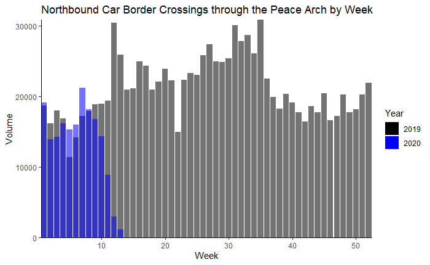

```r
colours <- c(`2019` = "black", `2020` = "blue")

peacearch_N_cars_byweek %>%
  ggplot(aes(x=Week, y = Volume, fill=as.character(Year))) +
  geom_bar(stat= "identity", position = "identity", aes(alpha = 0.3)) +
  scale_fill_manual(values = colours) +
  theme_classic() +
  scale_x_continuous(expand= c(0,0)) +
  scale_y_continuous(expand = c(0,0)) +
  guides(alpha = "none",
         fill = guide_legend(title = "Year")) +
  labs(title ="Northbound Car Border Crossings through the Peace Arch by Week")
```

```r
NA
```

Write a function to generate charts by lane type, summarizing all northbound border crossings

```r
query_by_crossing_id_and_lane <- function(id, lane) {

  url <- "http://www.cascadegatewaydata.com"
  path <- "Crossing/"
  query <- list(id=id, start="01/01/2019", end=end_date_char, data="sum-vol",
              dir="Northbound",lane=lane, dg = "Day",tg="Day", format="CSV" )

  data <- GET(url = url, path = path, query = query) %>% content()

  data

}

chart_volume_by_week <- function(lane){

  ids <- c(134,135,136,137)

  data <- purrr::map_dfc(ids, query_by_crossing_id_and_lane, lane = lane) %>%
    group_by(`Group Starts`) %>%
    summarize(sum = sum(`Sum - Volume (Peace Arch)`,
                      `Sum - Volume (Pacific Highway)`,
                      `Sum - Volume (Lynden/Aldergrove)`,
                      `Sum - Volume (Sumas/Huntingdon)`, na.rm = TRUE)) %>%
    mutate(Week = week(`Group Starts`),
           Year = year(`Group Starts`),
           DayOfWeek = wday(`Group Starts`)) %>%
    group_by(Year, Week) %>%
    mutate(First = paste(month(min(`Group Starts`), label = TRUE, abbr = TRUE), day(min(`Group Starts`)))) %>%
    group_by(Year, Week, First) %>%
    summarize(NumDays = n(),
              Volume = sum(sum, na.rm = TRUE)) %>%
    filter(NumDays == 7) %>% ungroup()


  ## Chart attributes
  colours <- c(`2019` = "black", `2020` = "blue")

  ## Date labels to better reference volumes
  ## Dates based on 2019 and are 1 day off for 2020 after Feb 29...
  x_labs <- data %>%
    filter(Year == 2019, Week %in% seq(1, 52, 4)) %>%
    pull(First)

  chart <- data %>%
    ggplot(aes(x=Week, y = Volume, fill=as.character(Year))) +
    geom_bar(stat= "identity", position = "identity", aes(alpha = 0.3)) +
    scale_fill_manual(values = colours) +
    theme_classic() +
    scale_x_continuous(expand= c(0,0), breaks = seq(1, 52, 4), labels = x_labs) +
    scale_y_continuous(expand = c(0,0)) +
    guides(alpha = "none",
           fill = guide_legend(title = "Year")) +
    labs(title =paste("Northbound", lane ,"Border Crossings by Week"))

  chart
}
```

```r
car_chart <- chart_volume_by_week("Car")
truck_chart <- chart_volume_by_week("Truck")
bus_chart <- chart_volume_by_week("Bus")
fast_chart <- chart_volume_by_week("Fast")
nexus_chart <- chart_volume_by_week("Nexus")
```

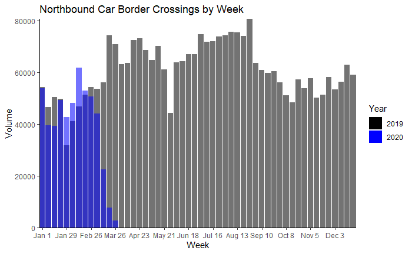

```r
car_chart
```

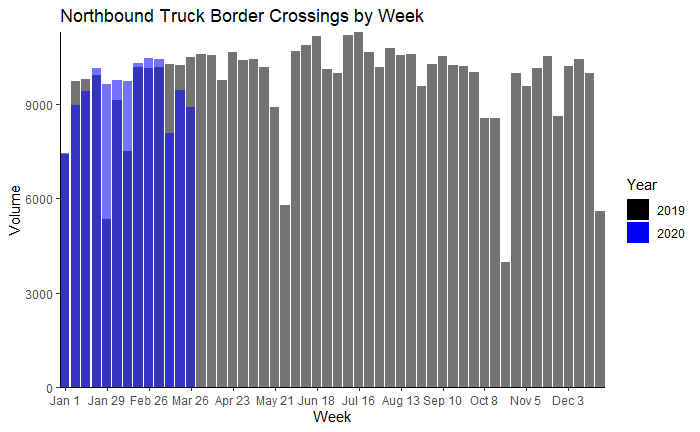

```r
truck_chart
```

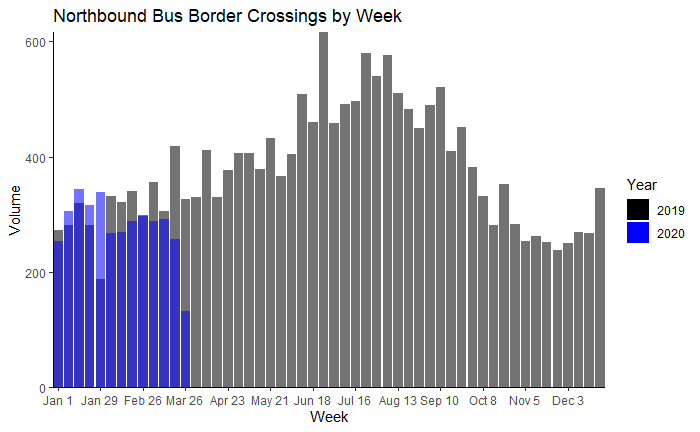

```r
bus_chart
```

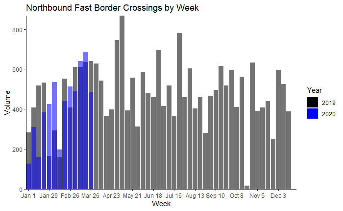

```r
fast_chart
```

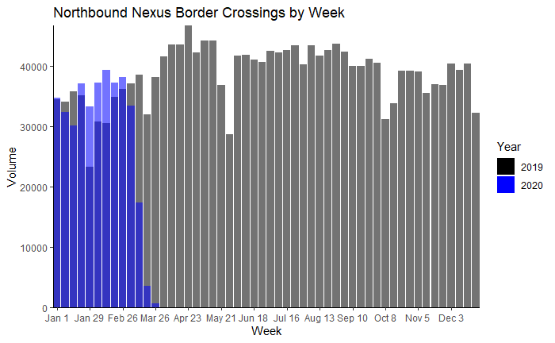

```r
nexus_chart
```